# Lab 02 - Plastic waste

## Exercise 2 - Create box plots to compare plastic waste distributions across continents

### I made three plots using the data after filtering out the extreme outliers of Trinidad and Tobago:

1. Simple plot of plastic waste by continent
2. Added individual data points to previous plot
3. Created a raincloud plot

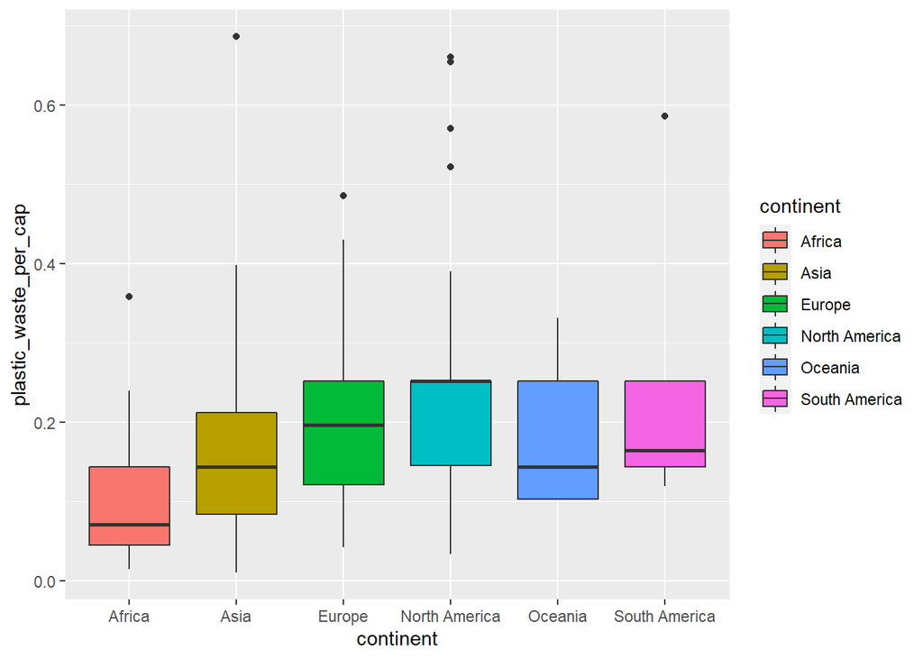

```r
ggplot(plastic_waste_filtered) +
  aes(x = continent, y = plastic_waste_per_cap,
      fill = continent) +
  geom_boxplot()
```

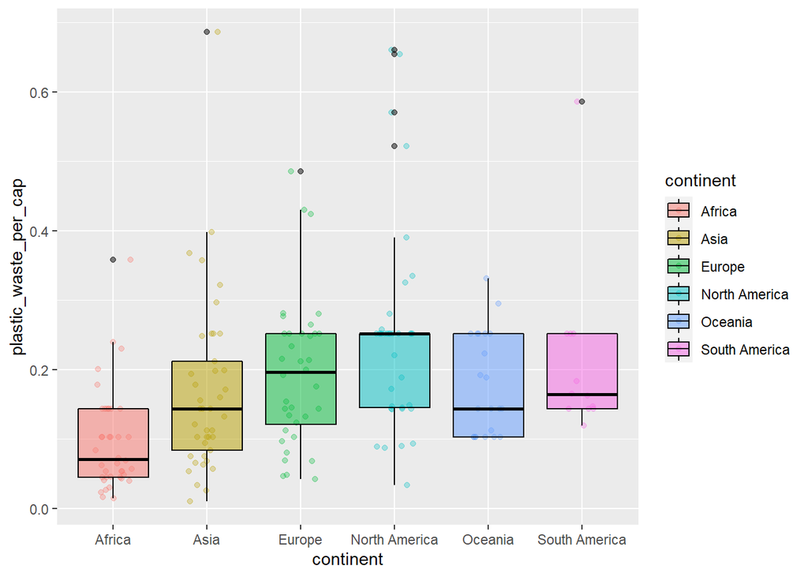

```r
ggplot(plastic_waste_filtered) +
  aes(x = continent, y = plastic_waste_per_cap,
      fill = continent, color = continent) +
  geom_jitter(height = 0, width = .2, alpha = .3) +
  geom_boxplot(color = "black", alpha = .5)
```

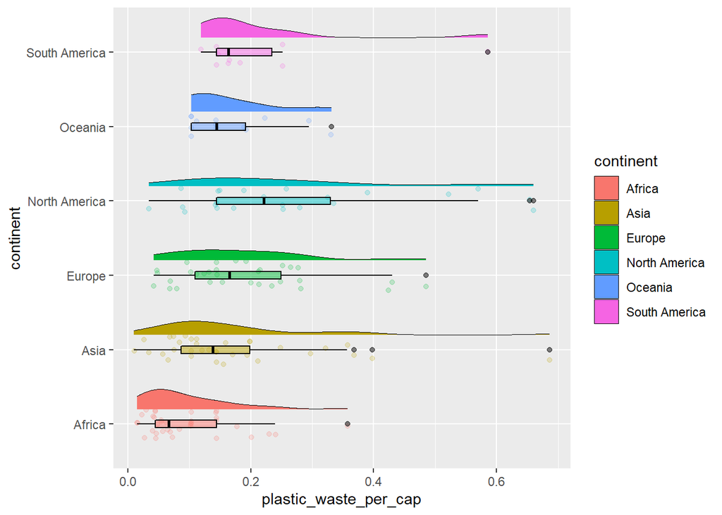

```r
ggplot(na.omit(plastic_waste_filtered)) +
  aes(x = plastic_waste_per_cap, y = continent,
      fill = continent, color = continent) +
  geom_jitter(height = .2, alpha = .2) +
  geom_boxplot(color = "black", alpha = .5, width = .1, size = .5) +
  ggdist::stat_slab(height = .3, color = "black", size = .2, aplha = .5, position = position_nudge(y = .2))
```

### Answer: The density and data points more clearly shows the shape of the distribution and the individual datapoints, compared to the boxplots.